# Data Analytics and Artificial Intelligence

## Module 2 - Project work

### FIRE CLASSIFICATION CHALLENGE

Marco Bruttocao (858067@stud.unive.it), Sayna Eghbalpour (870366@stud.unive.it),

Greta Giacomel (867057@stud.unive.it), Valentina Maccaferri (885948@stud.unive.it)

## Introduction

  ```
  T.Normalize( mean=[0.485, 0.456, 0.406],
                std=[0.229, 0.224, 0.225] )
  ```

As for as the construction of the model we decided to use the PyTorch framework, following a try, evaluate and improve method. We started from a simple idea and after each evaluation step of the model we tried to modify and implement new solutions to obtain the best solution possible.

## Setting up the environment

> In this section are grouped all the packages and modules we used during the project. Please notice that you need to mount the drive in order to run properly this notebook. The following code block serve this purpose.

```python
#-------------------libraries and modules
import sys
import os.path
from os import path

required = {'numpy', 'pandas', 'torch', 'seaborn', 'PIL', 'sklearn'}
missing = list()

def check_pkg(list_of_required):

    for pkg in list_of_required:
        if pkg in sys.modules:
            pass
        else:
            missing.append(pkg)

    if missing == {}:
        print('All required packages installed!')
    else:
        print('Missing packages: ', missing)

    if path.exists("/content/drive/MyDrive/Artificial_intelligence/Project/fire_dataset") == False:
      print('Checking Drive:\n')
      from google.colab import drive
      drive.mount('/content/drive')
    else:
      print('Drive already mounted')
      pass

check_pkg(required)
```

```
Missing packages:  ['sklearn', 'seaborn', 'torch']
```

```python
#-------------------libraries and modules
import time
start_time = time.time()

# Numpy
import numpy as np

# Pandas
import pandas as pd

# PyTorch
import torch
import torch.nn as nn
import torch.optim as optim
import torch.nn as nn
import torch.nn.functional as F
from torch.utils.data import TensorDataset, DataLoader
import torchvision.transforms as T
from torchsummary import summary
from torchvision import models

# Data visualization
import seaborn as sns
import matplotlib.pyplot as plt
import cv2
from google.colab.patches import cv2_imshow
import plotly.express as px
import plotly.graph_objects as go
from skimage.io import imread, imshow

# Other libraries
from PIL import Image
from collections import OrderedDict
from sklearn import datasets
from sklearn.model_selection import train_test_split
from sklearn.utils import shuffle
from sklearn.preprocessing import MinMaxScaler
from sklearn.metrics import classification_report
import glob
import io

#-------------------settings

# Seed
state = 1518

# Seaborn <- This will set seaborn as default
sns.set()
sns.set_style("whitegrid")
sns.set_context("paper")

# PyTorch <- This will automatically set the device, CPU or GPU
if torch.cuda.is_available():
    dev = "cuda:0"
else:
    dev = "cpu"

device = torch.device(dev)

print(f'Setup completed! Execution time: {round(time.time() - start_time,2)}s. \nDevice chosen (PyTorch): {device}')
```

```
Setup completed! Execution time: 1.08s.
Device chosen (PyTorch): cuda:0
```

## Functions

> In this section you can find all the funtions we defined to slim down the code

```python
# The aim of this function is to pre-process the images and store them into tensors
# on the chosen device

def processing_image_Pytorch(filepath):

  img = cv2.imread(filepath)

  img = cv2.cvtColor(img,cv2.COLOR_RGB2BGR)
  img = cv2.resize(img,(256,256))

  img_bw  = cv2.cvtColor(img, cv2.COLOR_RGB2GRAY)
  img_bw = cv2.resize(img_bw, (256,256))
  img_bw = cv2.merge([img_bw,img_bw,img_bw])

  lower = np.array([200,0,0], dtype="uint8")
  upper = np.array([255,255,129], dtype= "uint8")

  mask = cv2.inRange(img, lower, upper)
  output = cv2.bitwise_and(img, img, mask = mask)

  mask = cv2.bitwise_not(mask)
  background = cv2.bitwise_or(img_bw,img_bw,mask =  mask)

  opencvOutput = cv2.bitwise_or(output, background)

  pil_img = Image.fromarray(opencvOutput)

  preprocess = T.Compose([
   T.Resize(256),
   T.CenterCrop(256),
   T.RandomHorizontalFlip(p=0.5),
   T.ToTensor(),
   T.Normalize(
       mean=[0.485, 0.456, 0.406],
       std=[0.229, 0.224, 0.225]
     )
  ])

  x = preprocess(pil_img)
  x_g = x.to(device)
  return x_g


# This functions create the X and y datasets for training and test, pre-processing
# each image and storing them into tensors on the chosen device
def create_df_Pytorch(dataframe):

  X = []
  for i in range(len(dataframe.values[:,0])):
    X.append(processing_image_Pytorch(dataframe.values[i,0]))
  X = torch.stack(X)

  y = torch.from_numpy(np.array(dataframe.values[:,1], dtype="int8")) #.reshape(len(dataframe.values[:,1]),1))
  y_g = y.to(device)

  return X, y_g


# Simple post processing visualization
def processed(path):

    img = cv2.imread(path)
    img = cv2.cvtColor(img,cv2.COLOR_RGB2BGR)
    img = cv2.resize(img, (256,256))
    img_bw = cv2.cvtColor(img, cv2.COLOR_RGB2GRAY)
    img_bw = cv2.merge([img_bw,img_bw,img_bw])

    ##--define color range scale (BGR)
    lower = np.array([200,0,0], dtype="uint8")
    upper = np.array([255,255,129], dtype= "uint8")

    ##--mask creation
    mask = cv2.inRange(img, lower, upper)
    output = cv2.bitwise_and(img, img, mask = mask)

    ##--application of inverted mask on the bw version of image
    mask = cv2.bitwise_not(mask)
    background = cv2.bitwise_or(img_bw,img_bw,mask =  mask)

    ##--change back in final (join the images background with the fire image)
    opencvOutput = cv2.bitwise_or(output, background)

    plt.imshow(opencvOutput);
```

## Data gathering

In this section we gather the paths of each image. After that we create a dataset containing for each path (image) the corresponding target variable:

- 1 if the image contains fire
- 0 if the image does not contain fire

```python
# Here we gather the images paths

lst_fire_img = glob.glob('/content/drive/MyDrive/Artificial_intelligence/Project/fire_dataset/fire_images/*.png')
lst_non_fire_img = glob.glob('/content/drive/MyDrive/Artificial_intelligence/Project/fire_dataset/non_fire_images/*.png')

print("Number of images that contain fire: {}".format(len(lst_fire_img)))
print("Number of images that not contain fire: {}".format(len(lst_non_fire_img)))
```

```
Number of images that contain fire: 756
Number of images that not contain fire: 243
```

```python
# We create the dataset containing paths and labels

fire = pd.DataFrame(data = {"images":lst_fire_img, "target": np.ones(len(lst_fire_img), dtype=int)})

non_fire = pd.DataFrame(data = {"images":lst_non_fire_img,"target":np.zeros(len(lst_non_fire_img), dtype=int)})

df = pd.DataFrame(data = {"images":lst_fire_img + lst_non_fire_img,

                         "target": np.concatenate([np.ones(len(lst_fire_img),dtype= int),
                                                   np.zeros(len(lst_non_fire_img), dtype=int)])})

print('Dataframe Preview:')
display(df)
```

```
Dataframe Preview:
```

|  | images | target |
| --- | --- | --- |
| 0 | /content/drive/MyDrive/Artificial_intelligence... | 1 |
| 1 | /content/drive/MyDrive/Artificial_intelligence... | 1 |
| 2 | /content/drive/MyDrive/Artificial_intelligence... | 1 |
| 3 | /content/drive/MyDrive/Artificial_intelligence... | 1 |
| 4 | /content/drive/MyDrive/Artificial_intelligence... | 1 |
| ... | ... | ... |
| 994 | /content/drive/MyDrive/Artificial_intelligence... | 0 |
| 995 | /content/drive/MyDrive/Artificial_intelligence... | 0 |
| 996 | /content/drive/MyDrive/Artificial_intelligence... | 0 |
| 997 | /content/drive/MyDrive/Artificial_intelligence... | 0 |
| 998 | /content/drive/MyDrive/Artificial_intelligence... | 0 |

999 rows × 2 columns

```python
# Simple bar plot to compare how many fire and non-fire images we have

large_rockwell_template = dict(
    layout=go.Layout(title_font=dict(family="Rockwell", size=24)))

fig = go.Figure()

fig = go.Figure([go.Bar(x = ['Non Fire','Fire'],
                        y = [df[df['target'] == 0].count()[0],
                             df[df['target'] == 1].count()[0]],
                        marker_color= ['lightslategray', 'crimson'])])

fig.update_layout(  title='Dataframe Labels',
                    xaxis_title='Target',
                    yaxis_title='Count',
                    template=large_rockwell_template)

fig.show()
```

[interactive chart not shown]

## Image processing

> Here you can find an example of how the images are pre-processed. The first image is the original one while the following plot shows the processed image

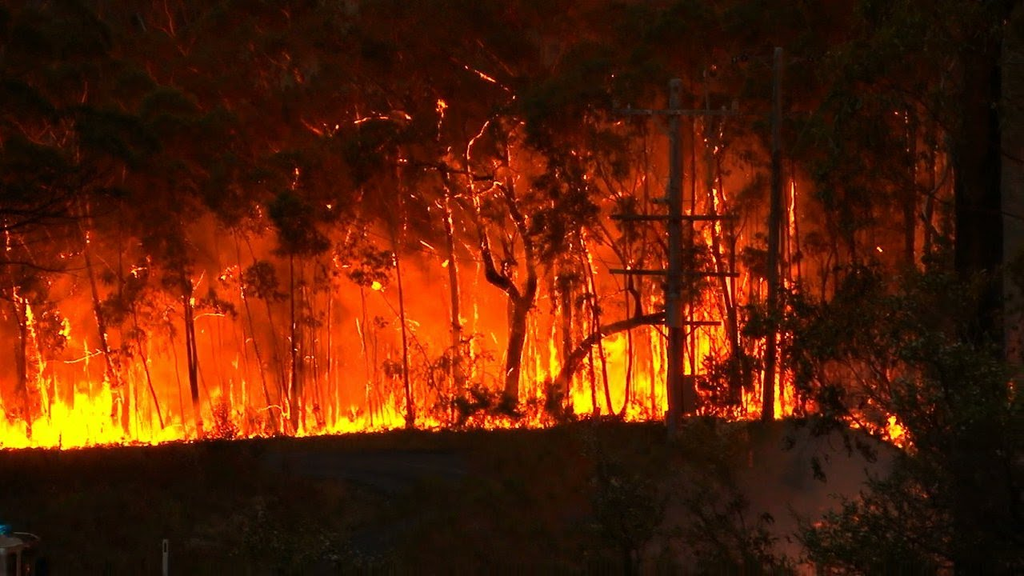

```python
path = '/content/drive/MyDrive/Artificial_intelligence/Project/fire_dataset/fire_images/fire.3.png'
cv2_imshow(cv2.imread(path))
```

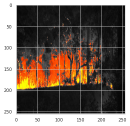

```python
processed(path)
```

## Creating the dataset, train and test split

```python
# Split dataframe in train and test
df_train, df_test = train_test_split(df, test_size = 0.33, stratify = df["target"])

# Call the function create dataframe with the nested function of image preprocessing

X_train, y_train = create_df_Pytorch(df_train)
X_test, y_test = create_df_Pytorch(df_test)

## Checking shapes
print(f'X_train shape: {X_train.shape}\nX_test shape: {X_test.shape}\ny_train shape: {y_train.shape}\ny_test shape: {y_test.shape}', sep = '' )
```

```
X_train shape: torch.Size([669, 3, 256, 256])
X_test shape: torch.Size([330, 3, 256, 256])
y_train shape: torch.Size([669])
y_test shape: torch.Size([330])
```

## PyTorch Model

> In this section you will find the actual model. First of all we decided to use the `TensorDataset` and the PyTorch data loading utility `DataLoader` to load the data into the model in batches. Then we defined the best model we found and implemented the training loop, plotting the results of the training

### Dataset and batch size initialization

```python
# Force tensor types into Float32 for X_train and X_test and Int64 for y_train and y_test

X_train,X_test= X_train.type(torch.FloatTensor), X_test.type(torch.FloatTensor)
y_train,y_test= y_train.type(torch.LongTensor), y_test.type(torch.LongTensor)

# Dataset implementation

train_dataset = TensorDataset(X_train,y_train)
test_dataset = TensorDataset(X_test,y_test)

print("Shape of X_Train: {}.".format(X_train.shape), "y_train: {}".format(y_train.shape))
print("Shape of X_Test: {}.".format(X_test.shape), "y_test: {}".format(y_test.shape))
```

```
Shape of X_Train: torch.Size([669, 3, 256, 256]). y_train: torch.Size([669])
Shape of X_Test: torch.Size([330, 3, 256, 256]). y_test: torch.Size([330])
```

```python
# Batch sizes

batch_size = 64

train_loader = torch.utils.data.DataLoader(dataset=train_dataset,
                                           batch_size=batch_size,
                                           shuffle=True)

test_loader = torch.utils.data.DataLoader(dataset=test_dataset,
                                          batch_size=batch_size,
                                          shuffle=False)
```

### Model implementation

```python
# Best model

class Net(nn.Module):
    def __init__(self):
        super(Net, self).__init__()

        # convolutional layer
        self.conv1 = nn.Conv2d(3, 64, 8, stride = 1, padding = 3)
        # max pooling layer
        self.pool1 = nn.MaxPool2d(8, 8)

        self.conv2 = nn.Conv2d(64, 128, 8, stride = 1, padding = 3)
        self.pool2 = nn.MaxPool2d(4, 4)
        self.dropout = nn.Dropout(0.2)

        self.conv3 = nn.Conv2d(128, 256, 4, stride = 1, padding = 2)
        self.pool3 = nn.MaxPool2d(2, 2)

        self.fc1 = nn.Linear(256 * 4 * 4, 512)
        self.fc2 = nn.Linear(512, 84)
        self.fc3 = nn.Linear(84, 2)

        self.softmax = nn.LogSoftmax(dim=1)

    def forward(self, x):
        # add sequence of convolutional and max pooling layers
        x = self.pool1(F.relu(self.conv1(x)))
        x = self.pool2(F.relu(self.conv2(x)))
        x = self.dropout(x)
        x = self.pool3(F.relu(self.conv3(x)))
        #print("x before",x.shape) #check the shape
        x = x.view(-1, 256 * 4 * 4)
        x = F.relu(self.fc1(x))
        x = self.dropout(F.relu(self.fc2(x)))
        x = self.softmax(self.fc3(x))
        return x

model = Net().to(device)
```

```python
# Model hyperparameters

criterion = nn.CrossEntropyLoss()
learning_rate = 0.001
optimizer = torch.optim.Adam(model.parameters(), lr=learning_rate)
```

```python
# Model Summary
summary(model,(3,256,256))
```

```
----------------------------------------------------------------
        Layer (type)               Output Shape         Param #
================================================================
            Conv2d-1         [-1, 64, 255, 255]          12,352
         MaxPool2d-2           [-1, 64, 31, 31]               0
            Conv2d-3          [-1, 128, 30, 30]         524,416
         MaxPool2d-4            [-1, 128, 7, 7]               0
           Dropout-5            [-1, 128, 7, 7]               0
            Conv2d-6            [-1, 256, 8, 8]         524,544
         MaxPool2d-7            [-1, 256, 4, 4]               0
            Linear-8                  [-1, 512]       2,097,664
            Linear-9                   [-1, 84]          43,092
          Dropout-10                   [-1, 84]               0
           Linear-11                    [-1, 2]             170
       LogSoftmax-12                    [-1, 2]               0
================================================================
Total params: 3,202,238
Trainable params: 3,202,238
Non-trainable params: 0
----------------------------------------------------------------
Input size (MB): 0.75
Forward/backward pass size (MB): 33.36
Params size (MB): 12.22
Estimated Total Size (MB): 46.32
----------------------------------------------------------------
```

### Specific functions for training the model

```python
# This function adjust the learning rate after a pre-determined number of epochs
# where we noticed bouncing behaviors around local minimum
def adjust_learning_rate(epoch):

    lr = 0.001

    if epoch > 88:
        lr = lr / 100000000
    elif epoch > 80:
        lr = lr / 10000000
    elif epoch > 72:
        lr = lr / 1000000
    elif epoch > 50:
        lr = lr / 100000
    elif epoch > 38:
        lr = lr / 10000
    elif epoch > 24:
        lr = lr / 1000
    elif epoch > 10:
        lr = lr / 100
    elif epoch > 6:
        lr = lr / 10

# This function will save the model if the performance at some epoch is the
# best performance so far
def save_models(epoch):
    torch.save(model.state_dict(), "fire_{}.model".format(epoch))


# This function is used for testing purposes. It is directly called into the
# training loop where the test_accuracy is needed
def test ():
  model.eval()
  test_acc = 0.0
  # iterate over test data
  len(test_loader)
  for i, (images, target) in enumerate(test_loader):
    images, target = images.to(device), target.to(device)
      # forward pass
    outputs = model(images)
      # calculate the batch loss
    loss = criterion(outputs, target)#.reshape(len(test_loader),1))

    _, prediction = torch.max(outputs.data, 1)
    test_acc += torch.sum(prediction == target.data)

      # Compute the average acc and loss over all 10000 test images
  test_acc = test_acc / len(y_test)

  return test_acc
```

```python
# Here we store the accuracy and the loss for plotting purposes
test_accur_plot = []
train_accur_plot = []
loss_plot = []

# Actual training loop
def train(num_epochs):
    best_acc = 0.0

    for epoch in range(num_epochs):
        model.train()
        train_acc = 0.0
        train_loss = 0.0

        for i, (images, labels) in enumerate(train_loader):
          images, labels = images.to(device), labels.to(device)
          images.requires_grad=True
          # Clear all accumulated gradients
          optimizer.zero_grad()
          # Predict classes using images from the test set
          outputs = model(images)
          # Compute the loss based on the predictions and actual labels
          loss = criterion(outputs, labels)
          # Backpropagate the loss
          loss.backward()

          # Adjust parameters according to the computed gradients
          optimizer.step()

          train_loss += loss.item() * images.size(0)
          _, prediction = torch.max(outputs.data, 1)

          train_acc += torch.sum(prediction == labels.data)

        # Call the learning rate adjustment function
        adjust_learning_rate(epoch)

        # Compute the average acc and loss over all training images
        train_acc = train_acc / len(y_train)
        train_loss = train_loss / len(y_train)

        global train_accur_plot
        train_accur_plot.append(train_acc.cpu().detach().numpy())


        global loss_plot
        loss_plot.append(float(train_loss))


        # Evaluate on the test set
        test_acc = test()

        global test_accur_plot
        test_accur_plot.append(test_acc.cpu().detach().numpy())


        # Save the model if the test acc is greater than our current best
        if test_acc > best_acc:
            save_models(epoch)
            best_acc = test_acc
            print("Chekcpoint saved! -> Epoch {}, Train Accuracy: {} , TrainLoss: {} , Test Accuracy: {}".format(epoch, train_acc, train_loss,test_acc))

        # Print the metrics
        if epoch % 10 == 0:
          print("Epoch {}, Train Accuracy: {} , TrainLoss: {} , Test Accuracy: {}".format(epoch, train_acc, train_loss,test_acc))

    train_accur_plot = np.array(train_accur_plot)
    loss_plot = np.array(loss_plot)
    test_accur_plot = np.array(test_accur_plot)
```

### Train loop call

```python
# Calling the train loop
epochs = 100
train(epochs)
```

```
Chekcpoint saved! -> Epoch 0, Train Accuracy: 0.7563527822494507 , TrainLoss: 0.7439913901602028 , Test Accuracy: 0.7575757503509521
Epoch 0, Train Accuracy: 0.7563527822494507 , TrainLoss: 0.7439913901602028 , Test Accuracy: 0.7575757503509521
Chekcpoint saved! -> Epoch 5, Train Accuracy: 0.7877429127693176 , TrainLoss: 0.26161797799069786 , Test Accuracy: 0.9666666388511658
Chekcpoint saved! -> Epoch 6, Train Accuracy: 0.9491778612136841 , TrainLoss: 0.2187006390682785 , Test Accuracy: 0.9727272391319275
Epoch 10, Train Accuracy: 0.9566516876220703 , TrainLoss: 0.11249921195799281 , Test Accuracy: 0.9636363387107849
Chekcpoint saved! -> Epoch 15, Train Accuracy: 0.9730941653251648 , TrainLoss: 0.08958522954841544 , Test Accuracy: 0.9757575392723083
Epoch 20, Train Accuracy: 0.9686098694801331 , TrainLoss: 0.0958343219062138 , Test Accuracy: 0.9727272391319275
Chekcpoint saved! -> Epoch 21, Train Accuracy: 0.9715994000434875 , TrainLoss: 0.09284956668613559 , Test Accuracy: 0.9787878394126892
Epoch 30, Train Accuracy: 0.9551569223403931 , TrainLoss: 0.14052233050935115 , Test Accuracy: 0.9636363387107849
Epoch 40, Train Accuracy: 0.9671151041984558 , TrainLoss: 0.0885431796134142 , Test Accuracy: 0.9575757384300232
Epoch 50, Train Accuracy: 0.9970104694366455 , TrainLoss: 0.01056288783292332 , Test Accuracy: 0.9636363387107849
Epoch 60, Train Accuracy: 0.980567991733551 , TrainLoss: 0.04722055690070706 , Test Accuracy: 0.9575757384300232
Epoch 70, Train Accuracy: 0.9656203389167786 , TrainLoss: 0.12497626383815334 , Test Accuracy: 0.9484848380088806
Epoch 80, Train Accuracy: 0.9925261735916138 , TrainLoss: 0.031626749420413255 , Test Accuracy: 0.9757575392723083
Epoch 90, Train Accuracy: 0.9955157041549683 , TrainLoss: 0.02705463663200181 , Test Accuracy: 0.960606038570404
```

```python
# Plotting train accuracy VS test accuracy
fig = go.Figure()
fig.add_trace(go.Scatter(x=np.arange(0, epochs), y=train_accur_plot,
                    mode='lines',
                    name='Train accuracy',
                    line=dict(color='royalblue', width=2,dash='dot')))
fig.add_trace(go.Scatter(x=np.arange(0, epochs), y=test_accur_plot,
                    mode='lines',
                    name='Test accuracy',
                    line=dict(color='coral', width=2)))

dic = dict(enumerate(test_accur_plot))
val = max(dic.values())

def get_key(val):
    for key, value in dic.items():
         if val == value:
             return key

fig.add_trace(go.Scatter(x=[get_key(val)], y=[val],
                    mode='markers',
                    name='Max accuracy',
                    line=dict(color='crimson', width=1)))


fig.update_layout(title='Train vs Test Accuracy',
                   xaxis_title='Epochs',
                   yaxis_title='Accuracy',
                   template=large_rockwell_template)
fig.show()
```

[interactive chart not shown]

```python
# Plotting losses
fig = go.Figure()
fig.add_trace(go.Scatter(x=np.arange(0, epochs), y=loss_plot,
                    mode='lines',
                    name='Loss',
                    line=dict(color='blue', width=2)))
fig.update_layout(title='Loss',
                   xaxis_title='Epochs',
                   yaxis_title='Loss',
                   template=large_rockwell_template)
fig.show()
```

[interactive chart not shown]

## Submit your own image

> In this section we tested the model submitting images that we collected with the help of 'Vigili Del Fuoco' of Bologna.

```python
def print_img(filepath):
  #--Print image with real shapes and colour
  img = cv2.imread(filepath)
  img = cv2.cvtColor(img,cv2.COLOR_RGB2BGR)
  img = cv2.resize(img, (256,256))
  img_bw = cv2.cvtColor(img, cv2.COLOR_RGB2GRAY)
  img_bw = cv2.merge([img_bw,img_bw,img_bw])

  ##--define color range scale (BGR)
  lower = np.array([200,0,0], dtype="uint8")
  upper = np.array([255,255,129], dtype= "uint8")

  ##--mask creation
  mask = cv2.inRange(img, lower, upper)
  output = cv2.bitwise_and(img, img, mask = mask)

  ##--application of inverted mask on the bw version of image
  mask = cv2.bitwise_not(mask)
  background = cv2.bitwise_or(img_bw,img_bw,mask =  mask)

  ##--change back in final (join the images background with the fire image)
  opencvOutput = cv2.bitwise_or(output, background)

  ##--Define space for images printing
  fig=plt.figure(figsize=(10, 7))
  row = 1
  columns = 2

  #--Prediction generation
  img_t = processing_image_Pytorch(filepath)
  img_t = torch.unsqueeze(img_t,0)

  model.eval()
  img_out = model(img_t)
  _, prediction = torch.max(img_out,1)

  #--Result
  if prediction == 0:
    plt.title("No Fire Detected",
              fontdict={'color' : 'grey','weight': 'bold','size': 18})
    plt.axis("off")

    fig.add_subplot(row,columns,1)
    plt.title("Original Image")
    plt.imshow(img)

    fig.add_subplot(row,columns,2)
    plt.title("Processed Image")
    plt.imshow(opencvOutput)
  else:
    plt.title("Warning! Fire detected",
              fontdict={'color' : 'red','weight': 'bold','size': 18})
    plt.axis("off")

    fig.add_subplot(row,columns,1)
    plt.title("Original Image")
    plt.imshow(img)

    fig.add_subplot(row,columns,2)
    plt.title("Processed Image")
    plt.imshow(opencvOutput)
```

### Two images trial

[figure not shown]

```python
#--Image submit and print of the result
filepath = "img_new.jpg"
print_img(filepath)
```

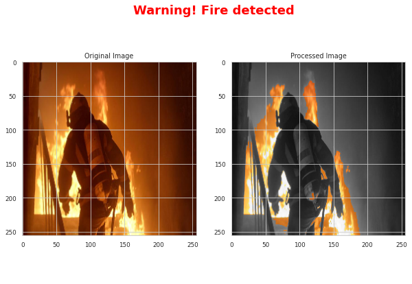

```python
#--Image submit and print of the result
filepath = "img.jpeg"
print_img(filepath)
```

## Other Models

> In this section we simply saved the previous models we tried to implement that have less accuracy in predicting the right target

```python
# Model 1

class Net(nn.Module):
    def __init__(self):
        super(Net, self).__init__()
        # convolutional layer
        self.conv1 = nn.Conv2d(3, 64, 3)
        self.conv2 = nn.Conv2d(64, 32, 3)
        # max pooling layer
        self.pool = nn.MaxPool2d(2, 2)
        # convolutional layer
        self.conv3 = nn.Conv2d(32, 64, 3)

        self.fc1 = nn.Linear(64*47*47, 128)
        self.fc2 = nn.Linear(128, 2)

        self.softmax = nn.LogSoftmax(dim=1)

    def forward(self, x):
        # add sequence of convolutional and max pooling layers
        x = F.relu(self.conv1(x))
        x = self.pool(F.relu(self.conv2(x)))
        x = self.pool(F.relu(self.conv3(x)))

        #print("x before",x.shape) #check the shape
        x = x.view(-1, 64 * 47 * 47)
        x = self.fc1(x)
        x = self.softmax(self.fc2(x))
        return x
```

```python
# Model 2

class Net(nn.Module):
    def __init__(self):
        super(Net, self).__init__()
        # convolutional layer
        self.conv1 = nn.Conv2d(3, 32, 3, stride = 1, padding = 2)
        # max pooling layer
        self.pool = nn.MaxPool2d(4, 4)
        self.conv2 = nn.Conv2d(32, 64, 3, stride = 1, padding = 2)
        self.dropout = nn.Dropout(0.2)
        self.conv3 = nn.Conv2d(64, 32, 3, stride = 1, padding = 2)
        self.fc1 = nn.Linear(32*17*17, 256)
        self.fc2 = nn.Linear(256, 84)
        self.fc3 = nn.Linear(84,2)
        self.softmax = nn.LogSoftmax(dim=1)

    def forward(self, x):
        # add sequence of convolutional and max pooling layers
        x = self.pool(F.relu(self.conv1(x)))
        x = F.relu(self.conv2(x))
        x = self.dropout(x)
        x = self.pool(F.relu(self.conv3(x)))
        #print("x before",x.shape) #check the shape
        x = x.view(-1, 32 * 17 * 17)
        x = F.relu(self.fc1(x))
        x = self.dropout(F.relu(self.fc2(x)))
        x = self.softmax(self.fc3(x))
        return x
```